# Lista 3

Guilherme Schneider Markus 00330054 Lisiane Bueno Peitz (00172039)

**Exercício 1)** Considere o resíduo de Pearson estimado para os Modelos Lineares Generalizados, dado por

$$\hat{r_i} = \frac{\sqrt{\phi}(y_i -
\hat\mu_i)}{\sqrt{V(\hat\mu_i)}}$$

1. Encontre o resíduo estimado de Pearson estimado para o modelo Binomial(n,π), com função de probabilidade dada por

$$f(y;\mu, \upsilon) = \binom{n}{y} \pi^y
(1-\pi)^{n-y}$$

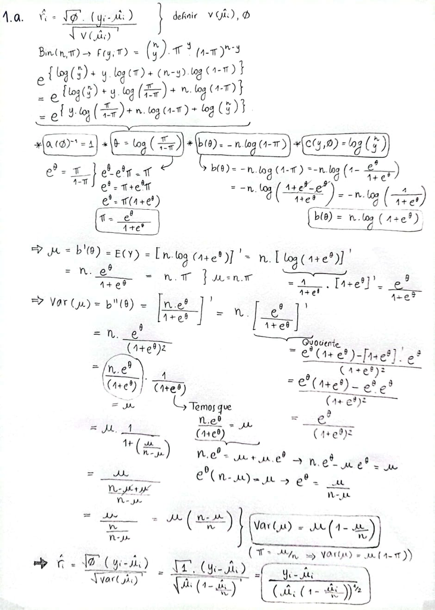

2. Encontre o resíduo estimado de Pearson estimado para o modelo Binomial Negativo(µ, k), com função de probabilidade dada por

$$f(y;\mu,k)=
\frac{\Gamma(k+y)}{\Gamma(k)y!} \frac{\mu^yk^k}{(\mu+k)^{k+y}},
\hspace{0.2cm} y=0,1,2,..., k,\mu >0$$

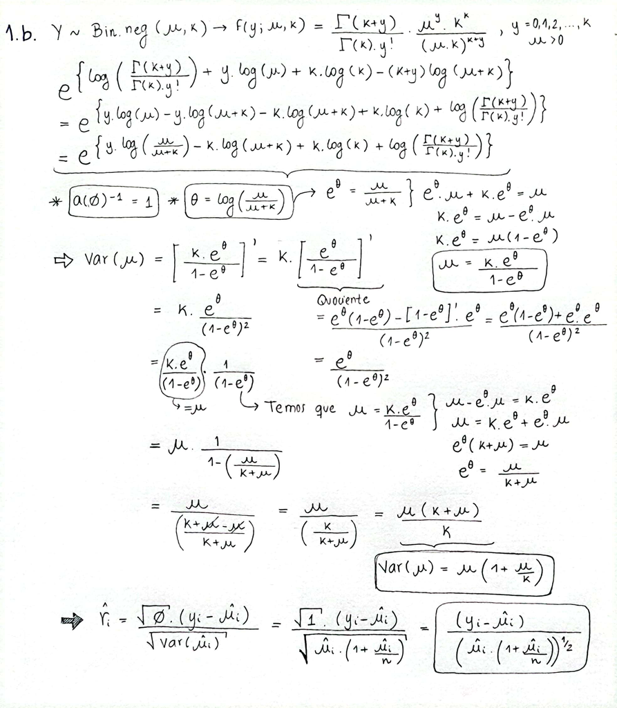

**Exercício 2)** Encontre o resíduo padronizado para o modelo Gama(µ, ν), com função densidade de probabilidade dada por

$$f(y;\mu,\upsilon)=\frac{(\frac{\upsilon}{\mu})^\upsilon}{\Gamma(\upsilon)}y^{\upsilon-1}exp\bigg\{-\frac{y\upsilon}{\mu}\bigg\}\hspace{0.2cm}
y>0, \hspace{0.2cm} \upsilon,\mu>0$$

Considere o resíduo padronizado dada por

$$\hat{t}_{S_{i}} = \frac{\sqrt{\phi}(y_i
- \hat\mu_i)}{\sqrt{\hat{V_i}(1-\hat{h_{ii}})}}$$

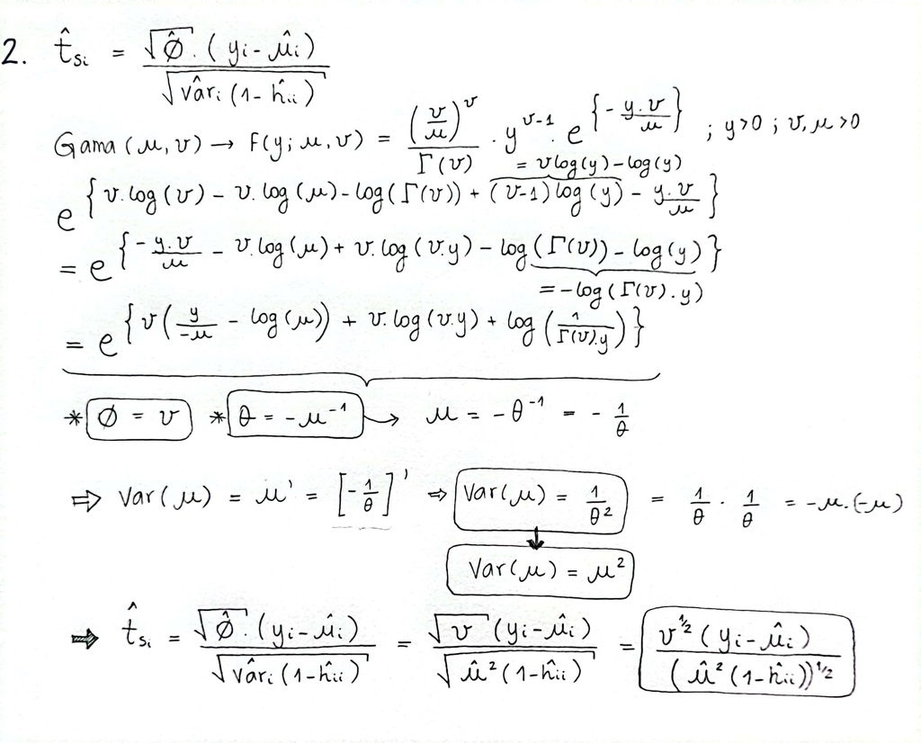

**Exercício 3)** A versão padronizada para os resíduos mais utilizada em Modelos Lineares Generalizados é dada por

$$\hat{t}_{D_{i}} = \frac{\sqrt{\phi}d(y_i
, \hat\mu_i)}{\sqrt{1-\hat{h_{ii}}}}$$

em que $d(y_i , \hat\mu_i) = \pm \sqrt{2} \{y_i(\tilde{\theta_i}- \hat{\theta_i}) + (b(\hat{\theta_i})- b(\tilde{\theta_i}))\}^{1/2}$.

Encontre a forma do resíduo tˆDi para o modelo Normal Inverso(µ, $\sigma^2$), com função densidade de probabilidade dada por

$$f(y;\mu,\upsilon)=\bigg(\frac{1}{2\pi\sigma^2y^3}\bigg)^{1/2}
exp \bigg[-\frac{(y-\mu)^2}{2\mu^2\sigma^2y}\bigg], \hspace{0.2cm}
y>0$$

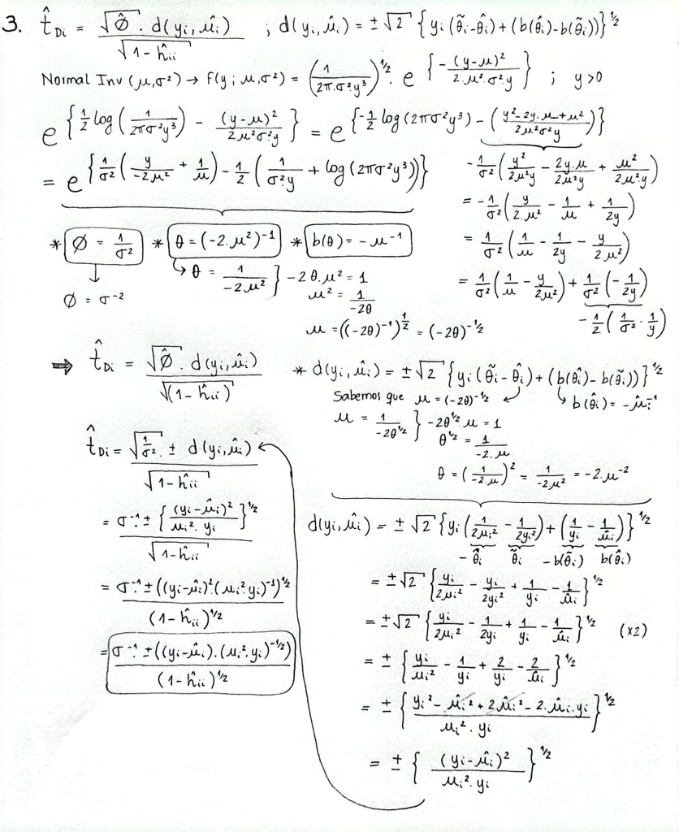

**Exercício 4)** Obtenha a expressão para o Critério de Informação de Akaike (AIC) para o modelo Poisson(µ). Sugestão: utilize o cálculo da função desvio.

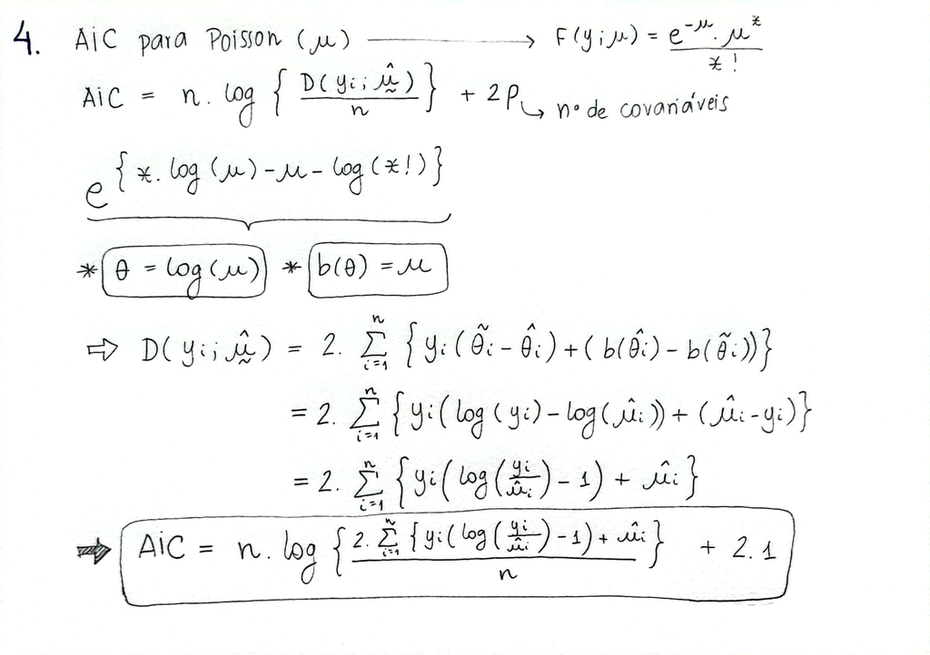

**Exercício 5)** Considere o modelo de mistura gerado pelas seguintes especificações. Seja Y |z uma variável aleatória com média z e variância z, ou seja, Y |z tem distribuição Poisson. Sabe-se que Z não é observável e tem distribuição Exponencial com parâmetro $\lambda$. Encontre a função de probabilidade resultante dessa mistura.

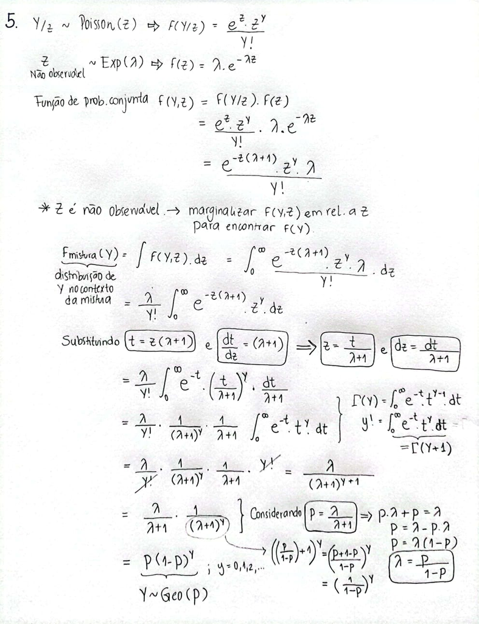

**Bibliotecas**

```r
library(kableExtra)
library(ggplot2)
library(dplyr)
library(ggthemes)
library(stats)
library(tidyverse)
library(qqplotr)
library(gridExtra)
library(broom)
library(car)
library(tidyr)
library(formattable)
library(gt)
library(gtsummary)
library(MASS)
library(lmtest)
library(hnp)
```

**Exercício 6)** Considere descreve um experimento com duas espécies de *rotifers*, um tipo microscópico de invertebrado aquático. Foi utilizado um método indireto que consiste em centrifugar os animais em recipientes com densidades relativas de uma determinada substância e então utilizar uma regressão logística para ajustar a proporção de *rotifers* que permanece suspensa segundo a densidade relativa. A densidade relativa de cada espécie pode ser estimada pela $DL_{50}$, que nesse caso representa a densidade relativa da substância que deixa suspenso 50% de rotifers.

**Descrição do dados**

No arquivo **rotifers.txt** são apresentados para cada espécie a densidade relativa da substância, o número de rotifers expostos e o número de *rotifers* em suspensão.

```r
kableExtra::kable(head(rotifers))
```

| Densidade | Suspensos | Expostos | Especie |
| --- | --- | --- | --- |
| 1.019 | 11 | 58 | 1 |
| 1.020 | 7 | 86 | 1 |
| 1.021 | 10 | 76 | 1 |
| 1.030 | 19 | 83 | 1 |
| 1.030 | 9 | 56 | 1 |
| 1.030 | 21 | 73 | 1 |

**Objetivo**

O objetivo do experimento é determinar a densidade relativa para cada uma das espécies e utilizar uma regressão logística para ajustar a proporção de *rotifers* que permanece suspensa segundo a densidade relativa.

**Análise descritiva**

1. Faça os gráficos de Boxplots da variável resposta pelas variáveis explicativas. Interprete os gráficos.

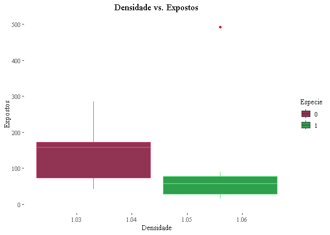

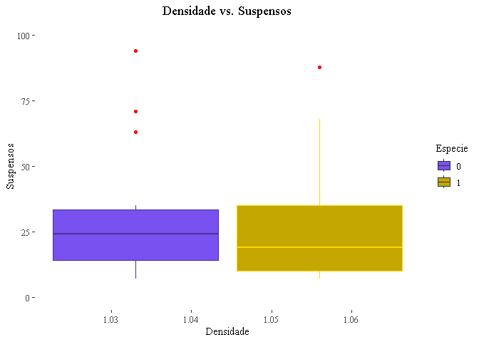

Podemos ver nos gráficos acima que, para a variável do número de rotifers expostos, a espécie 0 possui maiores valores do que a espécie 1 e maior variabilidade. Enquanto 50% dos dados da espécie 0 possuem o número de rotifers expostos abaixo de 157, 50% dos dados da espécie 1 possuem o número de rotifers expostos abaixo de 57.

Já para a variável do número de rotifers em suspensão, embora a espécie 0 possua maiores valores do que a espécie 1, esses dois grupos parecem ser similares entre si. Enquanto 50% dos dados da espécie 0 possuem o número de rotifers em suspensão abaixo de 25.50, 50% dos dados da espécie 1 possuem o número de rotifers em suspensão abaixo de 19.50.

Se o número de rotifers em suspensão entre as duas espécies é similar e o número de rotifers expostos é maior para a espécie 0, podemos dizer que na estatística descritiva as proporções de sucesso são diferentes entre as espécies.

2. Apresente em uma tabela a análise descritiva dos dados (para todas as variáveis).

**Medidas Descritivas por Espécies**

Medidas Descritivas por Espécie

| Medida | Espécie 0 Densidade | Espécie 0 Suspensos | Espécie 0 Expostos | Espécie 1 Densidade | Espécie 1 Suspensos | Espécie 1 Expostos |
| --- | --- | --- | --- | --- | --- | --- |
| Média | 1.045 | 43.800 | 143.950 | 1.045 | 50.250 | 74.300 |
| Mediana | 1.044 | 25.500 | 157.000 | 1.044 | 19.500 | 57.000 |
| Desvio Padrão | 0.017 | 47.446 | 77.537 | 0.017 | 105.649 | 101.503 |
| Variância | 0.000 | 2251.116 | 6012.050 | 0.000 | 11161.776 | 10302.853 |
| Valor mínimo | 1.019 | 7.000 | 42.000 | 1.019 | 7.000 | 14.000 |
| Valor máximo | 1.070 | 178.000 | 286.000 | 1.070 | 488.000 | 492.000 |

Podemos ver que as medidas descritivas para a variável densidade é igual para ambas as espécies.

Para a variável do número de rotifers em suspensão, vemos que a espécie 1 possui maior média, menor mediana e maior variabilidade em relação à espécie 0. Para a variável do número de rotifers expostos, vemos que a espécie 0 possui maior média, maior mediana e menor variabilidade em relação à espécie 1.

3. Ajuste um MLG com distribuição Binomial e apresente uma tabela com os valores estimados, intervalos de confiança, erro padrão e p-valor.

**Ajuste de um modelo linear generalizado**

Seja $Y_{ij}$ o número de animais da i-ésima espécie que permanecem suspensos num recipiente com densidade relativa $d_j$ da solução, onde foram colocados $n_{ij}$ *rotifers*.

Assumimos inicialmente que $Y_{ij} = B(n_{ij},\pi_{ij}), \hspace{0.2cm}i = 1, 2\hspace{0.2cm} e\hspace{0.2cm} j = 1, . . . , 20$, em que:

$$log\bigg\{\frac{\pi_{ij}}{1-\pi_{ij}}\bigg\} =
\alpha_i + \beta_id_j$$

```r
modelo_binomial_logit <- glm(cbind(Suspensos, Expostos - Suspensos) ~ Densidade * Especie, family = binomial(link = "logit"), data = rotifers)

modelo_binomial_probit <- glm(cbind(Suspensos, Expostos - Suspensos) ~ Densidade * Especie, family = binomial(link = "probit"), data = rotifers)

modelo_binomial_loglog <- glm(cbind(Suspensos, Expostos - Suspensos) ~ Densidade * Especie, family = binomial(link = "cloglog"), data = rotifers)

modelo_binomial_cauchit <- glm(cbind(Suspensos, Expostos - Suspensos) ~ Densidade * Especie, family = binomial(link = "cauchit"), data = rotifers)
```

|  | AIC | BIC | HQ | AICc |
| --- | --- | --- | --- | --- |
| Logito | 298.2835 | 301.6613 | 299.5048 | 293.7835 |
| Probito | 316.8998 | 320.2775 | 318.1211 | 312.3998 |
| Complemento Log-log | 269.0641 | 272.4419 | 270.2854 | 264.5641 |
| Cauchy | 240.1159 | 243.4937 | 241.3372 | 235.6159 |

Através da tabela acima, comparamos os tipos de métodos utilizados em cada modelo, e o link `Cauchy` apresentou um melhor ajuste em todos os critérios, porém o exercício nos pede para aplicarmos uma regressão logística.

**Modelo linear generalizado: Modelo logístico com distribuição Binomial**

| Termo | Estimativa | Erro Padrão | Estatística t | P-valor (aprox.) | IC-LI (2,5%) | IC-LS (97,5%) |
| --- | --- | --- | --- | --- | --- | --- |
| (Intercept) | -114.352 | 4.034 | -28.345 | 0.000 | -122.420 | -106.598 |
| Densidade | 108.746 | 3.857 | 28.191 | 0.000 | 101.332 | 116.460 |
| Especie1 | 4.629 | 6.598 | 0.702 | 0.483 | -8.464 | 17.431 |
| Densidade:Especie1 | -3.077 | 6.329 | -0.486 | 0.627 | -15.354 | 9.487 |

4. Apresente o modelo Logístico com os valores estimados.

$$log\bigg\{\frac{\pi_{ij}}{1-\pi_{ij}}\bigg\} =
\alpha_i + \beta_id_j$$

Para a especie `Polyathra major` temos:

$\hat\alpha_1 = −109,72 \hspace{0.2cm} e \hspace{0.2cm} \hat\beta_1 = 105,67$

$$log\bigg\{\frac{\pi_{1j}}{1-\pi_{1j}}\bigg\} =
−109,72 + 105,67d_j$$

Para a especie `Keratella cochlearis` temos:

$\hat\alpha_2 = −114,35 \hspace{0.2cm} e \hspace{0.2cm} \hat\beta_2 = 108,75$

$$log\bigg\{\frac{\pi_{2j}}{1-\pi_{2j}}\bigg\} =
−114,35 + 108,75d_j$$

De uma forma geral, considerando que o r vai tomar a espécie `Keratella cochlearis` como referência, temos o modelo logístico:

$$log\bigg\{\frac{\pi_{ij}}{1-\pi_{ij}}\bigg\} =
−114,35 + 108,75 X_{1ij}+ 4,629X_{2ij}−3,077X_{1ij}X_{2ij}$$

$$\pi_{ij} = \frac{e^{−114,35 + 108,75
X_{1ij}+ 4,629X_{2ij}−3,077X_{1ij}X_{2ij}}}{1 + e^{−114,35 + 108,75
X_{1ij}+ 4,629X_{2ij}−3,077X_{1ij}X_{2ij}}}$$

$$OU$$

$$\pi_{ij} = \frac{1}{1 + e^{-(−114,35 +
108,75 X_{1ij}+ 4,629X_{2ij}−3,077X_{1ij}X2_{ij})}}$$

Supondo o modelo logístico com preditor linear $\boldsymbol{\eta} = \beta_i + \beta_2x$, a estimativa de máxima verossimilhança de $DL_p$ fica, pela propriedade de invariância, dada por:

$$\widehat{DL_{100p}}=\frac{1}{\hat{\beta_2}}\bigg[log\bigg(\frac{p}{1-p}\bigg)-\hat\beta_1\bigg]$$

no qual $\widetilde{\boldsymbol{\hat\beta}} = (\hat\beta_1, \hat\beta_2)$ é a nossa EMV.

```r
p = 0.5 # DL50
beta1 = modelo_binomial_logit[["coefficients"]][["Densidade"]]+modelo_binomial_logit[["coefficients"]][["Densidade:Especie1"]]
beta2 = modelo_binomial_logit[["coefficients"]][["Densidade"]]

(1/beta2)*(log(p/(1-p))-beta1)
```

```
## [1] -0.9717031
```

5. Apresente as razões de chances estimadas e faça a interpretação.

|  | Razão de chances | IC-LI (2.5%) | IC-LS (97,5%) |
| --- | --- | --- | --- |
| (Intercept) | 0.000000e+00 | 0.000000e+00 | 0.000000e+00 |
| Densidade | 1.689191e+47 | 8.794324e+43 | 3.244554e+50 |
| Especie1 | 1.024090e+02 | 0.000000e+00 | 4.232881e+07 |
| Densidade:Especie1 | 4.600000e-02 | 0.000000e+00 | 1.124675e+04 |

Se o rotifers for da espécie 1, eleva a razão de chance de Y (o número de animais da i-ésima espécie que permanecem suspensos num recipiente com densidade relativa $d_j$ da solução, onde foram colocados $n_{ij}$ *rotifers*) em 1.024090e+02 vezes.

6. Avalie se o modelo está bem ajustado.

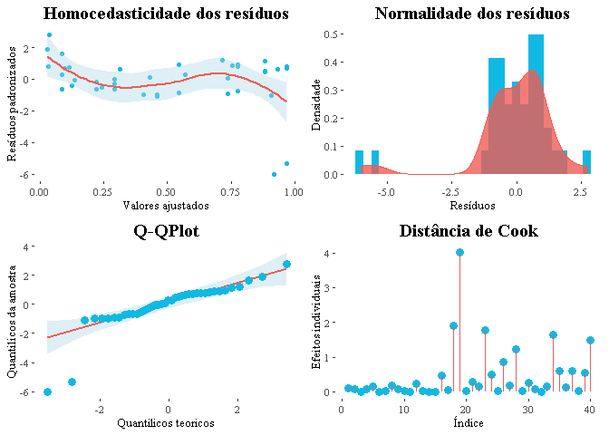

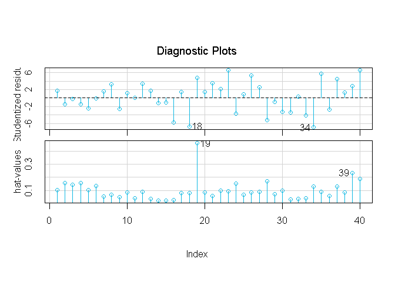

Os resíduos parecem estar normalmente distribuídos, porém, podemos ver que os resíduos ultrapassam os limites de 3 desvios para mais e para menos. Isso indica a possibilidade de sobredispersão no modelo. A sobredispersão é quando a variação observada excede aquela assumida pelo modelo.

Os resíduos studentizados são resíduos que são ajustados para terem uma distribuição t de Student com graus de liberdade adequados. Esses resíduos são úteis para identificar observações atípicas ou incomuns no modelo. No gráfico, vemos que as observações 18 e 34 estão um pouco mais longes de zero que as demais observações.

A distância de Cook é uma medida que indica o impacto de uma observação nos coeficientes do modelo quando essa observação é excluída. No gráfico, vemos que as observações 18 e 19 possuem valores de Cook maiores do que outras. Valores altos de Cook podem indicar observações que têm um impacto desproporcional nos resultados do modelo.

Alavancagem (leverage) é uma medida da influência que uma observação tem sobre o ajuste do modelo. No gráfico, vemos que as observações 19 e 39 têm valores de alavancagem maiores do que as outras observações. Observações com alta alavancagem podem ter um impacto maior no ajuste do modelo.

7. Avalie se existe sobredispersão. Caso tenha sobredispersão, apresente novas estimativas para os parâmetros.

Com isso obtivemos um valor do desvio residual de $D(y;\hat{\mu}) =$ 434.0178638, indicando que temos um ajuste inadequado. Os gráficos utilizados na questão anterior mostram uma possível sobredispersão.

A soma dos quadrados dos resíduos é uma medida usada para quantificar a discrepância entre os valores observados e os valores ajustados pelo modelo. A soma dos quadrados dos resíduos do modelo é maior do que os graus de liberdade (12.0560518 vezes maior), e a razão $resíduos/gl$ deveria ser próxima de 1. Como a razão é maior do que 1, isto indica a presença de sobredispersão no modelo. A sobredispersão é quando a variação observada excede aquela assumida pelo modelo.

Novas estimativas para os parâmetros: Ajuste para um modelo quase-binomial.

O modelo quase-binomial é um tipo de modelo de regressão que é usado quando os pressupostos da distribuição binomial não são completamente atendidos. Quando ajustamos um modelo quase-binomial, levamos em conta a sobredispersão e vamos ter estimativas mais precisas dos parâmetros do modelo.

```r
modelo_final <- glm(cbind(Suspensos, Expostos - Suspensos) ~ Densidade * Especie, data = rotifers, family = quasibinomial())
```

| Termo | Estimativa | Erro Padrão | Estatística t | P-valor (aprox.) | IC-LI (2,5%) | IC-LS (97,5%) |
| --- | --- | --- | --- | --- | --- | --- |
| (Intercept) | -114.352 | 14.953 | -7.647 | 0.000 | -146.017 | -87.012 |
| Densidade | 108.746 | 14.298 | 7.606 | 0.000 | 82.601 | 139.023 |
| Especie1 | 4.629 | 24.457 | 0.189 | 0.851 | -46.151 | 51.309 |
| Densidade:Especie1 | -3.077 | 23.460 | -0.131 | 0.896 | -47.810 | 45.698 |

Podemos ver que as estimativas para os parâmetros no modelo quase-binomial possuem intervalos de confiança maiores do que o modelo logístico utilizado anteriormente. Com um $R^2$:

```r
with(summary(modelo_final), 1 - modelo_final[["deviance"]]/modelo_final[["null.deviance"]])
```

```
## [1] 0.8635588
```

**Exercício 7)** Em um estudo de seguimento em que doutores Britânicos foram acompanhados durante a década de 50 e observado, em particular, a ocorrência de mortes por câncer de pulmão segundo o consumo médio diário de cigarros e a faixa etária. Esses dados estão disponíveis no arquivo **breslow.txt**.

```r
breslow <- read.csv("breslow.txt", sep="")
```

**Descrição do dados**

• O número de casos de câncer;

• Total de pessoas-anos;

• Número de cigarros por dia (1:não fumante, 2:1-9 cigarros, 3:10-30 cigarros, 4:+ 30 cigarros);

• Faixa-etária (1:40-49 anos, 2:50-59 anos, 3:60-69 anos, 4:70-80 anos).

```r
breslow$ncigarros <- as.factor(breslow$ncigarros)
breslow$fxetaria <- as.factor(breslow$fxetaria)
kableExtra::kable(head(breslow))
```

| ncancer | totalpes | ncigarros | fxetaria |
| --- | --- | --- | --- |
| 0 | 33679.0 | 1 | 1 |
| 3 | 21131.5 | 1 | 2 |
| 0 | 10599.0 | 1 | 3 |
| 3 | 4495.5 | 1 | 4 |
| 0 | 6002.5 | 2 | 1 |
| 1 | 4396.0 | 2 | 2 |

**Análise descritiva**

1. Apresente em uma tabela a análise descritiva dos dados.

Medidas Descritivas por Consumo de Cigarros

| Medida | Não Fumantes ncancer | Não Fumantes totalpes | 1 a 9 Cigarros ncancer | 1 a 9 Cigarros totalpes | 10 a 30 Cigarros ncancer | 10 a 30 Cigarros totalpes | Acima de 30 Cigarros ncancer | Acima de 30 Cigarros totalpes |
| --- | --- | --- | --- | --- | --- | --- | --- | --- |
| Média | 1.50 | 17476.25 | 1.75 | 3719.12 | 30.50 | 19470.00 | 16.50 | 4152.50 |
| Mediana | 1.50 | 15865.25 | 2.00 | 3604.75 | 35.00 | 19350.00 | 13.50 | 4673.75 |
| Desvio Padrão | 1.73 | 12802.17 | 1.50 | 1889.76 | 17.08 | 13083.04 | 14.06 | 2606.83 |
| Variância | 3.00 | 163895466.08 | 2.25 | 3571200.56 | 291.67 | 171165894.17 | 197.67 | 6795553.83 |
| Valor mínimo | 0.00 | 4495.50 | 0.00 | 1664.50 | 7.00 | 4765.50 | 3.00 | 769.00 |
| Valor máximo | 3.00 | 33679.00 | 3.00 | 6002.50 | 45.00 | 34414.50 | 36.00 | 6493.50 |

Medidas Descritivas por Faixa Etária

| Medida | 40 a 49 anos ncancer | 40 a 49 anos totalpes | 50 a 59 anos ncancer | 50 a 59 anos totalpes | 60 a 69 anos ncancer | 60 a 69 anos totalpes | 70 a 80 anos ncancer | 70 a 80 anos totalpes |
| --- | --- | --- | --- | --- | --- | --- | --- | --- |
| Média | 2.50 | 19994.25 | 12.25 | 14362.50 | 20.00 | 7537.50 | 15.50 | 2923.62 |
| Mediana | 1.50 | 19840.75 | 9.50 | 13812.50 | 19.50 | 7032.75 | 7.00 | 3080.00 |
| Desvio Padrão | 3.32 | 16229.28 | 13.00 | 10480.76 | 21.49 | 5200.48 | 20.02 | 2007.58 |
| Variância | 11.00 | 263389628.75 | 168.92 | 109846355.50 | 462.00 | 27045007.17 | 401.00 | 4030366.40 |
| Valor mínimo | 0.00 | 5881.00 | 1.00 | 4396.00 | 0.00 | 2813.50 | 3.00 | 769.00 |
| Valor máximo | 7.00 | 34414.50 | 29.00 | 25429.00 | 41.00 | 13271.00 | 45.00 | 4765.50 |

Podemos ver que conforme a faixa etária e o consumo de cigarros aumentam, a quantidade média de mortes também aumenta, considerando a quantidade total de pessoas.

2. Faça gráficos para ver se há sobredispersão nos dados.

A avaliação da sobredispersão nos dados se refere a análises exploratórias e cálculos estatísticos que examinam a variabilidade dos dados em relação ao que seria esperado em situações de dispersão adequada.

Comparando o índice de dispersão calculado com o que seria esperado para uma distribuição teórica específica. Por exemplo, se você estiver trabalhando com dados de contagem, a distribuição Poisson pressupõe variância igual à média. Se o índice de dispersão for consideravelmente maior do que 1, isso sugere sobredispersão. Observando os dados acima, vemos claramente o afastamento da média em relação a variância.

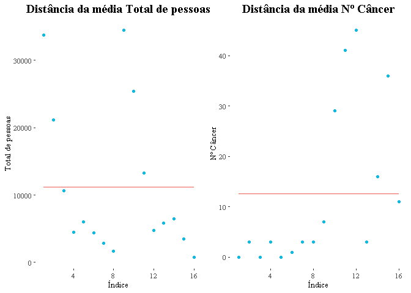

**Ajuste de um modelo linear generalizado**

Denote por $Y_{ij}$ o número de mortes para o i-ésimo nível de consumo e j-ésima faixa etária, i, j = 1, …, 4. Vamos suponha que $Y_{ij} \sim P(\lambda{ij},t_{ij})$, em que $\lambda{ij}$ é a taxa média de mortes por unidade de tempo para o consumo i e faixa etária j.

3. Ajuste um MLG com distribuição Poisson e apresente uma tabela com os valores estimados, intervalos de confiança, erro padrão e p-valor.

O modelo saturado nesse caso é dado por:

$$log\lambda_{ij} = \alpha +
\beta_{i}+\gamma_j+ \delta_{ij}$$

em que $\beta_1=0$, $\beta_i$ é o efeito da i-ésima classe de consumo de cigarros com relação à classe de não fumantes, i = 2, 3, 4, $\gamma_1=0$, $\gamma_1$ é o efeito da j-ésima faixa etária com relação à faixa etária de 40 − 49 anos e $\delta_{ij}$ denota a interação entre faixa etária e consumo de cigarros, em que $\delta_{i1}= \delta_{1j} = 0$ , para i, j = 1, . . . , 4.

| #Df | LogLik | Df | Chisq | Pr(>Chisq) |
| --- | --- | --- | --- | --- |
| 16 | -25.73965 | NA | NA | NA |
| 7 | -31.69415 | -9 | 11.90898 | 0.2184892 |

O teste de ausência de interação, $H_0: \delta_{ij} = 0, \forall_{ij}$, contra a alternativa de pelo menos um parâmetro diferente de zero forneceu $\xi_{RV}$ = 11.909 (9 graus de liberdade) que equivale a um p-valor de 0.2185.

Com isso, concluímos que o modelo sem interação é melhor neste caso.

```r
modelo_1 <- glm(ncancer ~ ncigarros + fxetaria + totalpes,
               family = poisson(link = "log"), data = breslow)
```

|  | Estimate | Std..Error | z.value | Pr…z.. |
| --- | --- | --- | --- | --- |
| (Intercept) | -0.8784984 | 0.7390574 | -1.1886740 | 0.2345680 |
| ncigarros2 | 0.0302600 | 0.5932475 | 0.0510074 | 0.9593197 |
| ncigarros3 | 3.0409102 | 0.4207491 | 7.2273724 | 0.0000000 |
| ncigarros4 | 2.2810065 | 0.4682019 | 4.8718434 | 0.0000011 |
| fxetaria2 | 1.5203985 | 0.3625381 | 4.1937623 | 0.0000274 |
| fxetaria3 | 1.8985947 | 0.4411999 | 4.3032523 | 0.0000168 |
| fxetaria4 | 1.5615505 | 0.5430643 | 2.8754431 | 0.0040346 |
| totalpes | -0.0000129 | 0.0000212 | -0.6105929 | 0.5414691 |

```r
modelo_2 <- glm(ncancer ~ ncigarros + fxetaria + log(totalpes),
               family = poisson(link = "log"), data = breslow)
```

|  | Estimate | Std..Error | z.value | Pr…z.. |
| --- | --- | --- | --- | --- |
| (Intercept) | -20.010047 | 6.2682887 | -3.192266 | 0.0014116 |
| ncigarros2 | 2.386127 | 0.8846605 | 2.697224 | 0.0069920 |
| ncigarros3 | 2.754778 | 0.4254359 | 6.475189 | 0.0000000 |
| ncigarros4 | 4.891404 | 0.9259268 | 5.282711 | 0.0000001 |
| fxetaria2 | 1.928926 | 0.3679055 | 5.242994 | 0.0000002 |
| fxetaria3 | 3.593260 | 0.6109600 | 5.881334 | 0.0000000 |
| fxetaria4 | 5.435500 | 1.2421954 | 4.375720 | 0.0000121 |
| log(totalpes) | 1.838814 | 0.6097733 | 3.015570 | 0.0025650 |

O ajuste do modelo com log(totalpes) forneceu a EMV = 1.8388 significativo para o modelo, com erro de 0.6098. Podemos usar log(totalpes) no modelo.

```r
# Valores do modelo acima com log(totalpes)
theta_hat <-1.8388  # Estimador do parâmetro
theta_0 <- 1      # Valor da hipótese nula
se_theta_hat <- 0.6098  # Erro padrão do estimador
# Calcula a estatística de teste de Wald
wald_statistic <- ((theta_hat - theta_0) / se_theta_hat)^2
# Graus de liberdade para a distribuição qui-quadrado (1 no caso do teste de uma única restrição)
df <- 1
# Calcula o valor-p
p_value <- 1 - pchisq(wald_statistic, df)
```

O teste de Wald para testarmos $H_0:\theta = 1$ contra $H_0:\theta \neq 1$ forneceu o valor $\xi_{RV}$ = 1.89209, com p-valor de 0.16897, indicando que o modelo pode ser ajustado com log(totalpes) como sendo offset.

A utilização do termo de “offset” é comum em modelos de regressão Poisson quando se deseja considerar uma taxa ou densidade ao invés de uma contagem direta. Quando a variável é incluída como um termo de “offset”, se modela a relação entre as duas variáveis em termos de proporção (totalpes e ncancer), permitindo que a variável da resposta (ncancer) seja ajustada em relação à outra variável(totalpes).

```r
# Ajustar o modelo Poisson
modelo_poisson <- glm(ncancer ~ ncigarros + fxetaria + offset(log(totalpes)),
               family = poisson(link = "log"), data = breslow)
```

| Termo | Estimativa | Erro Padrão | Estatística t | P-valor (aprox.) | IC-LI (2,5%) | IC-LS (97,5%) |
| --- | --- | --- | --- | --- | --- | --- |
| (Intercept) | -11.424 | 0.509 | -22.424 | 0.000 | -12.526 | -10.510 |
| ncigarros2 | 1.409 | 0.557 | 2.531 | 0.011 | 0.306 | 2.543 |
| ncigarros3 | 2.866 | 0.418 | 6.854 | 0.000 | 2.135 | 3.804 |
| ncigarros4 | 3.758 | 0.427 | 8.803 | 0.000 | 3.005 | 4.708 |
| fxetaria2 | 1.769 | 0.347 | 5.095 | 0.000 | 1.133 | 2.509 |
| fxetaria3 | 2.897 | 0.336 | 8.630 | 0.000 | 2.289 | 3.619 |
| fxetaria4 | 3.791 | 0.341 | 11.121 | 0.000 | 3.170 | 4.521 |

Ou seja, teremos um aumento (exponencial) da taxa média de mortes com o aumento da faixa etária e/ou com o aumento do consumo médio diário de cigarros.

4. Ajuste um MLG com distribuição Binomial Negativa.

```r
# Ajustar o modelo Binomial Negativa
modelo_binomial_negativa <- glm.nb(ncancer ~ ncigarros + fxetaria + offset(log(totalpes)),
               data = breslow)
```

| Termo | Estimativa | Erro Padrão | Estatística t | P-valor (aprox.) | IC-LI (2,5%) | IC-LS (97,5%) |
| --- | --- | --- | --- | --- | --- | --- |
| (Intercept) | -11.424 | 0.509 | -22.424 | 0.000 | -12.526 | -10.510 |
| ncigarros2 | 1.409 | 0.557 | 2.531 | 0.011 | 0.306 | 2.543 |
| ncigarros3 | 2.866 | 0.418 | 6.853 | 0.000 | 2.135 | 3.804 |
| ncigarros4 | 3.758 | 0.427 | 8.803 | 0.000 | 3.005 | 4.708 |
| fxetaria2 | 1.769 | 0.347 | 5.095 | 0.000 | 1.133 | 2.509 |
| fxetaria3 | 2.897 | 0.336 | 8.630 | 0.000 | 2.289 | 3.619 |
| fxetaria4 | 3.791 | 0.341 | 11.120 | 0.000 | 3.170 | 4.521 |

5. Ajuste um MLG com quase-verossimilhança.

```r
# Ajustar o modelo com quase-verossimilhança
modelo_quase_poisson <- glm(ncancer ~ ncigarros + fxetaria + offset(log(totalpes)),
               family = quasipoisson(), data = breslow)
```

| Termo | Estimativa | Erro Padrão | Estatística t | P-valor (aprox.) | IC-LI (2,5%) | IC-LS (97,5%) |
| --- | --- | --- | --- | --- | --- | --- |
| (Intercept) | -11.424 | 0.527 | -21.669 | 0.000 | -12.569 | -10.481 |
| ncigarros2 | 1.409 | 0.576 | 2.446 | 0.037 | 0.266 | 2.585 |
| ncigarros3 | 2.866 | 0.433 | 6.623 | 0.000 | 2.112 | 3.841 |
| ncigarros4 | 3.758 | 0.442 | 8.506 | 0.000 | 2.981 | 4.746 |
| fxetaria2 | 1.769 | 0.359 | 4.923 | 0.001 | 1.112 | 2.537 |
| fxetaria3 | 2.897 | 0.347 | 8.339 | 0.000 | 2.269 | 3.647 |
| fxetaria4 | 3.791 | 0.353 | 10.746 | 0.000 | 3.150 | 4.549 |

6. Avalie os modelos apresentados acima.

Obtivemos valores do desvio residual de:

- $D(y;\hat{\mu}) =$ 11.9089821 - para o modelo Poisson
- $D(y;\hat{\mu}) =$ 11.9076076 - para o modelo binomial negativa,
- $D(y;\hat{\mu}) =$ 11.9089821, para o modelo quase-poisson;

Entre os modelos acima, o que possui menor deviance é o modelo com distribuição binomial negativa. Porém, os três modelos possuem deviance parecidas.

|  | AIC | BIC | HQ | AICc |
| --- | --- | --- | --- | --- |
| Poisson | 38.69415 | 41.39821 | 38.83262 | 38.69415 |
| Bin. Negativa | 38.69455 | 41.39861 | 38.83302 | 38.69455 |

Através da tabela acima, só conseguimos comparar os dois primeiros modelos, pois o modelo quase-poisson não possui tais critérios. O modelo da distribuição Poisson possui um melhor ajuste em todos os critérios (os menores valores para AIC, BIC, HQ e AICc). Porém, os dois modelos possuem valores muito parecidos.

Shapiro-Wilk normality test

| Modelo | Estatística W | P-valor |
| --- | --- | --- |
| modelo_poisson[["residuals"]] | 0.8927248 | 0.0615268 |
| modelo_binomial_negativa[["residuals"]] | 0.8927283 | 0.0615347 |
| modelo_quase_poisson[["residuals"]] | 0.8927248 | 0.0615268 |

Os resíduos tiveram a normalidade aceita para os três modelos.

Temos que para os 3 modelos, iremos ter praticamente os mesmos gráficos para analisar seus pressupostos, como mostra abaixo:

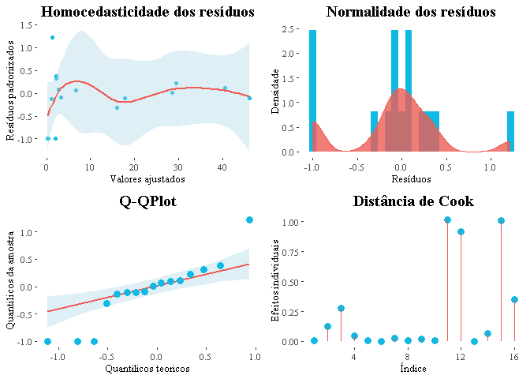

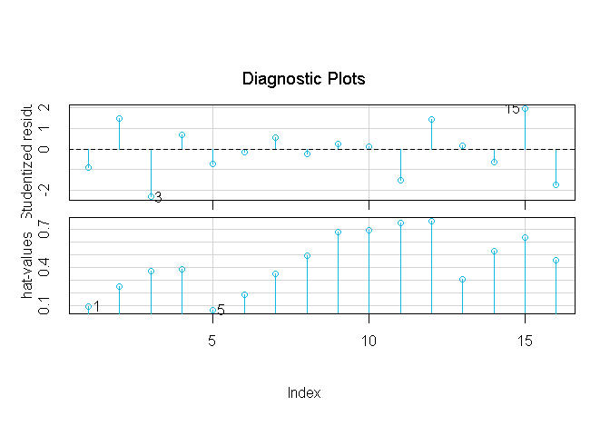

Utilizando o gráfico envelope do pacote `hnp`:

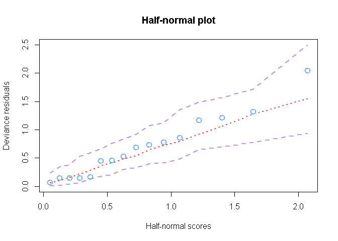

Comparando os coeficientes dos 3 modelos temos:

|  | Model 1 | Model 2 | Model 3 |
| --- | --- | --- | --- |
| (Intercept) | -11.4240738 | -11.4240738 | -11.4240738 |
| SE | 0.5094605 | 0.5094497 | 0.5272131 |
|  | NA | NA | NA |
| ncigarros2 | 1.4088181 | 1.4088172 | 1.4088172 |
| SE | 0.5566505 | 0.5566427 | 0.5760517 |
|  | NA | NA | NA |
| ncigarros3 | 2.8661969 | 2.8661946 | 2.8661946 |
| SE | 0.4182136 | 0.4182040 | 0.4327859 |
|  | NA | NA | NA |
| ncigarros4 | 3.7580084 | 3.7580261 | 3.7580261 |
| SE | 0.4269212 | 0.4269115 | 0.4417971 |
|  | NA | NA | NA |
| fxetaria2 | 1.7692667 | 1.7692570 | 1.7692570 |
| SE | 0.3472802 | 0.3472645 | 0.3593729 |
|  | NA | NA | NA |
| fxetaria3 | 2.8972680 | 2.8972562 | 2.8972562 |
| SE | 0.3357357 | 0.3357195 | 0.3474253 |
|  | NA | NA | NA |
| fxetaria4 | 3.7914286 | 3.7914434 | 3.7914434 |
| SE | 0.3409484 | 0.3409321 | 0.3528197 |
|  | NA | NA | NA |

7. Avalie se existe sobredispersão. Caso tenha sobredispersão, qual modelo você indicaria.

A soma dos quadrados dos resíduos é uma medida usada para quantificar a discrepância entre os valores observados e os valores ajustados pelo modelo.

A soma dos quadrados dos resíduos dos modelos é maior do que os graus de liberdade:

- 1.3232202 vezes maior no modelo Poisson;
- 1.3230675 vezes maior no modelo Binomial Negativa;
- 1.3232202 vezes maior no modelo quase-poisson.

A razão $resíduos/gl$ deve ser próxima de 1, e está.

isto indica que temos uma sobredispersão muito pequena nos modelos. A sobredispersão é quando a variação observada excede aquela assumida pelo modelo. Então pelo critério que deve ser o menor possível, indicamos o `Modelo binomial negativo`, que possui também um $R^2=$ 0.9747992, o maior entre os modelos.